# Clase 9: Georreferenciación y análisis de mapas históricos — concesiones forestales en La Araucanía (1916)

## Paso 18 | Calcular los centroides de cada concesión

**45.** Con la capa de concesiones (con área elipsoidal añadida) seleccionada, ve a **Vectorial → Herramientas de geometría → Centroides…**

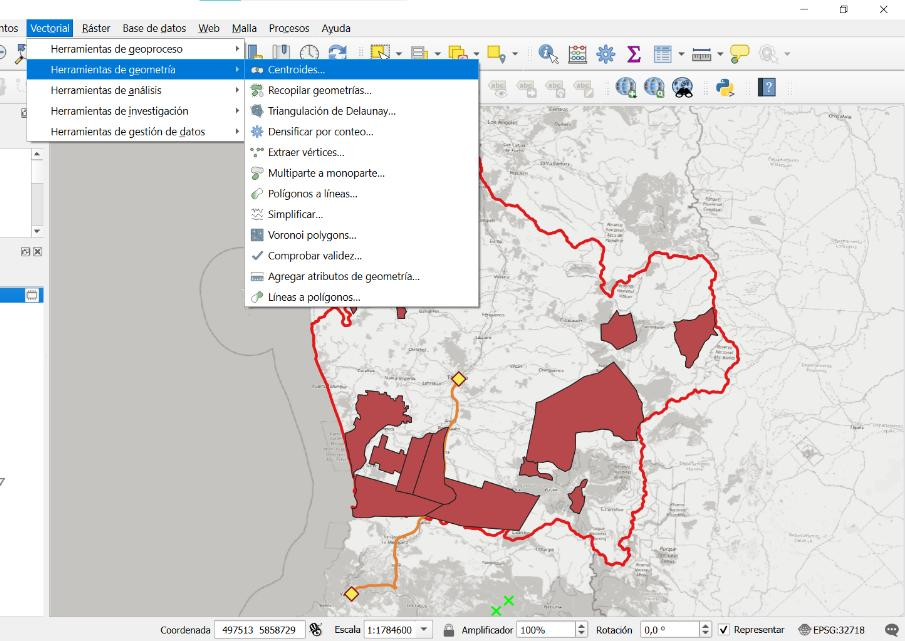

Menú Vectorial > Herramientas de geometría > Centroides.

**46.** Configura:

- **Capa de entrada:** la capa con los atributos de geometría añadidos
- **Crear centroide para cada parte:** desactivado

[figure not shown]

Configuración del algoritmo Centroides.

**47.** *(Opcional)* En **Avanzado**, también selecciona **“Do not filter (Better Performance)”** para evitar problemas con polígonos irregulares.

[figure not shown]

Opciones avanzadas de Centroides: Do not filter.

**48.** Click en **Ejecutar**. Se creará una nueva capa de puntos llamada `Centroides`, con un punto en el centro de cada concesión. Renómbrala a `Concesiones_centroides` y guárdala en `datos/intermedios/`.

[figure not shown]

Mapa con los centroides de las concesiones — un punto en el centro de cada polígono.

**Tip**

**¿Para qué sirven los centroides?** El **centroide** representa el “centro de masa” de un polígono. En análisis espacial sirve para tareas como **calcular distancias entre objetos** (donde los polígonos son demasiado grandes para usarlos directamente), **etiquetar mapas**, o **simplificar representaciones geográficas**. En el siguiente paso lo usaremos para medir cercanía a las ciudades.

## Paso 19 | Matriz de distancia entre concesiones y ciudades

**Tip**

**¿Qué es una matriz de distancia?** Calcula la **distancia euclidiana** (línea recta, “vuelo de pájaro”) entre cada punto de una capa y cada punto de otra. En nuestro caso: la distancia desde el centroide de cada concesión hasta cada una de las dos ciudades — útil para identificar patrones espaciales, como concesiones que se concentran cerca de centros urbanos.

**49.** Ve a **Vectorial → Herramientas de análisis → Matriz de distancia…**

[figure not shown]

Menú Vectorial > Herramientas de análisis > Matriz de distancia.

**50.** Configura:

- **Capa de puntos de entrada:** `Concesiones_centroides`
- **Campo ID único de entrada:** `id`
- **Capa de puntos objetivo:** `Ciudades`
- **Campo ID único objetivo:** `id`
- **Tipo de matriz de salida:** **Matriz de distancia estándar (N × T)**
- **Usar sólo los puntos objetivo más cercanos (k):** `0` (todos)

Click en **Ejecutar**.

[figure not shown]

Configuración de la Matriz de distancia: centroides como entrada, ciudades como objetivo.

**51.** Se generará una capa de puntos con una columna por ciudad (`Matriz de distancia_1`, `Matriz de distancia_2`), donde cada celda contiene la **distancia lineal en metros** entre el centroide y la ciudad respectiva.

[figure not shown]

Tabla de atributos de la Matriz de distancia: una columna por ciudad, con la distancia en metros.

## Paso 20 | Unir la matriz de distancia a la capa de concesiones

**Tip**

**¿Por qué un join no espacial?** Necesitamos que la información de distancia (que está en la capa de centroides) **acompañe a los polígonos de concesiones** para poder simbolizarlos por distancia. Como los centroides comparten el mismo `id` que las concesiones, podemos hacer un **join por atributo** sin necesidad de operaciones espaciales.

**52.** Doble click sobre la capa `Concesiones_Forestales` (la que tiene el área elipsoidal) → **Propiedades → Uniones**. Click en el ícono **“+”** y configura:

- **Capa a unir:** `Matriz de distancia`
- **Campo de la unión:** `id`
- **Campo objetivo:** `id`

Click en **Aceptar** y luego **Aplicar**.

**53.** Abre la **tabla de atributos** de `Concesiones_Forestales` para verificar que ahora tiene las columnas `Matriz de distancia_1` y `Matriz de distancia_2` añadidas.

**54.** Abre la **Calculadora de Campos** y crea un campo nuevo:

- Marca **“Crear un campo nuevo”**
- **Nombre del campo:** `Distancia_min_ciudad`
- **Tipo de campo:** Whole Number (integer)
- **Expresión:**

```
Min("Matriz de distancia_1", "Matriz de distancia_2")
```

Click en **Aceptar**.

[figure not shown]

Calculadora de Campos con la fórmula Min para obtener la distancia mínima a las ciudades.

## Paso 21 | Mapa de cercanía a ciudades

**56.** Apaga las capas de contexto que no quieras mostrar (la imagen histórica, los centroides), y ve a **Proyecto → Nueva composición de impresión…** para confeccionar el diseño final del mapa con leyenda, escala y norte.

**Nota**

**PAUSA** — el mapa de cercanía debería verse así:

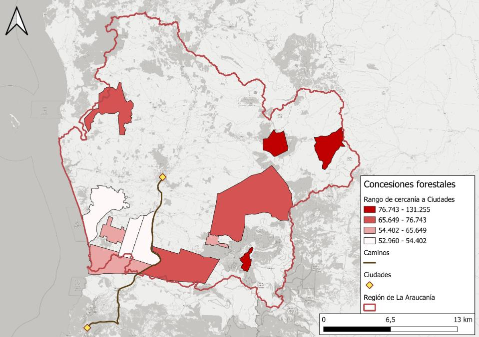

Mapa de cercanía: concesiones forestales coloreadas según la distancia mínima a Temuco o Valdivia.

## Paso 22 | Cargar el catastro vegetacional CONAF 2017

**57.** Ya con todos los elementos cartografiados y desarrollados, integraremos el **catastro vegetacional de la Región de La Araucanía del 2017** (CONAF). Esta capa contiene información sobre el **tipo de cobertura vegetal** actual de la región, lo que nos permitirá comparar con el mapa histórico georreferenciado de 1916.

**58.** Ve a **Capa → Añadir capa → Añadir capa vectorial…** y carga `datos/brutos/Catastro_Vegetacional_2017.gpkg`.

**Tip**

**¿Por qué este catastro?** El **Catastro y Evaluación de Recursos Vegetacionales Nativos** que mantiene CONAF es la base oficial del uso de suelo y la cobertura vegetal en Chile. La versión 2017 para La Araucanía usa el campo **`USO`** para clasificar cada polígono (Bosques, Terrenos Agrícolas, Áreas Urbanas e Industriales, Praderas y Matorrales, Cuerpos de Agua, etc.). Vamos a usar ese campo para construir una **simbología comparativa** con las concesiones de 1916.

## Paso 23 | Simbología basada en reglas para el catastro

**59.** Doble click sobre la capa del catastro → **Simbología**. Cambia el modo de simbología en la parte superior a **“Basado en reglas”**.

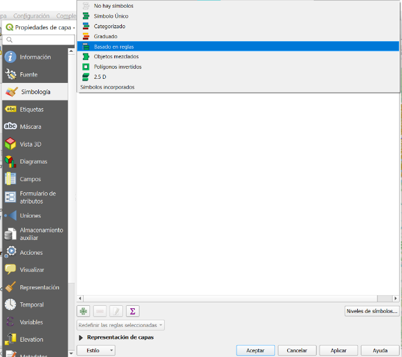

Cambiar el modo de simbología a Basado en reglas.

**60.** Click en **“+”** (nueva regla) para crear la **primera regla** — los **bosques**:

- **Etiqueta:** `Bosques`
- Click en el ícono **`ε`** (editor de expresiones)

[figure not shown]

Edit Rule con etiqueta “Bosque” y editor de expresiones.

**61.** En el Expression Builder, escribe:

```
"USO" = 'Bosques'
```

Click en **Aceptar**. Asigna un color verde a esta regla.

[figure not shown]

Expression Builder con la condición “USO” = ‘Bosques’.

**62.** Repite los pasos 60–61 para crear las dos reglas adicionales:

- **`Terrenos agrícolas`** (color rojo/marrón):

  ```
  "USO" = 'Terrenos Agrícolas'
  ```

- **`Otros elementos`** (color gris claro):

  ```
  "USO" IN ('Áreas Desprovistas de Vegetación', 'Áreas Urbanas e Industriales',
            'Praderas y Matorrales', 'Nieves Eternas y Glaciares',
            'Humedales', 'Cuerpos de Agua')
  ```

**Nota**

**Resultado de la simbología:** la capa del catastro vegetacional debería verse así, con tres categorías:

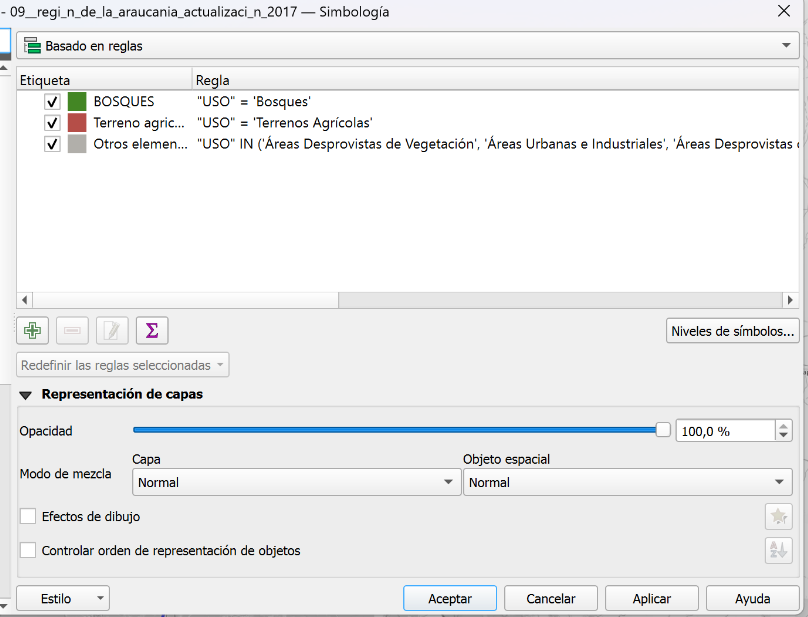

Simbología basada en reglas con tres categorías: Bosques, Terrenos agrícolas, Otros elementos.

## Paso 24 | Mapa final — huella de las concesiones de 1916 sobre el paisaje actual

**63.** Para producir el mapa comparativo final, ajusta el estilo de las capas:

- **`Concesiones_Forestales`:** simbología **categorizada** por el campo `Estado`. **Relleno transparente** (Sin relleno) y **borde** distinto para cada categoría:
  - `Existente` → borde grueso, color oscuro (ej. negro)
  - `Caducada` → borde grueso, color punteado o claro (ej. blanco)
- **`Catastro_Vegetacional_2017`:** simbología basada en reglas (paso 23). Considera bajar la opacidad ligeramente para que no quite protagonismo a los bordes de las concesiones.
- **`Region_Araucania`:** sin relleno, borde delgado.
- Apaga la imagen histórica y los centroides; mantén las ciudades y el camino.

**64.** Ve a **Proyecto → Nueva composición de impresión…** y arma el diseño final del mapa con título, leyenda, escala y norte.

**Nota**

**Resultado esperado:** el mapa final debería visualizarse así, con las concesiones de 1916 (contornos según estado) sobre el catastro vegetal actual (verdes / rojos / grises):

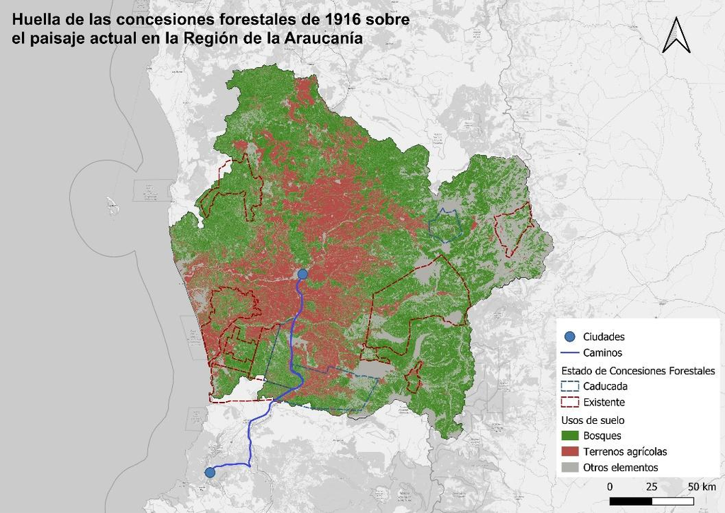

Mapa final: huella de las concesiones forestales de 1916 sobre el paisaje actual de La Araucanía.

## ¡Listo!

Has finalizado tus mapas y ejercicios. **Recuerda completar esta actividad y guardar tu carpeta para utilizarla en tu próximo portafolio.**

**Importante**

**Elige una o dos concesiones del mapa de 1916 para tu portafolio** y construye una breve narrativa visual a partir de los dos mapas que produjiste (cercanía a ciudades + huella sobre el paisaje 2017). Considera las siguientes preguntas guía:

1. El cálculo elipsoidal arrojó áreas que **no coinciden exactamente** con las hectáreas declaradas en el mapa de 1916. ¿Es esa diferencia una “imprecisión” del pasado, o también podría reflejar **decisiones políticas** sobre cómo se medía y registraba la tierra entregada a las concesiones? ¿Qué implicaría una u otra interpretación?
2. Mirando el mapa de cercanía: ¿las concesiones se distribuyen al azar, o se concentran cerca de **Temuco** y **Valdivia** y de la **vía principal** que las conecta? ¿Qué lectura económica y política haces de ese patrón?
3. En el mapa de huella sobre el catastro 2017: algunas concesiones **siguen siendo bosque**, otras pasaron a ser **terrenos agrícolas** o **áreas urbanas**. ¿Qué factores podrían explicar esas diferencias — la calidad del suelo, la accesibilidad, la **propiedad mapuche o no-mapuche** del territorio, las políticas estatales de los siglos XX y XXI? Apóyate en lo discutido en clase para argumentar.